# Final Report

Hongyan Xiao, Jiaqi Xia, Xiyu Hao, Xuelan Qian, Chao-Sheng Wu

12/13/2022

# I. Introduction

In a period of over two decades since the first review in 1995, millions of Amazon customers have contributed over a hundred million reviews to express opinions and describe their experiences regarding products on the Amazon.com website. Our dataset is the collection of reviews written in the Amazon.com marketplace and associated metadata from 1995 until 2015. And we are particularly interested in the star ratings and the review body.

The question we want to address is “What are the populars words in reviews for each Amazon category?”. To solve this problem, we used a local machine to analyze one category and broadcast our results to all categories by CHTC. Finally, we generated a dataset with the top ten most mentioned keywords for each indivual dataset. And, we merged the separate data sets we obtained into a total one to facilitate our use of graphical visualization.

# II. Body

## B. Statistical Computation

### 1. For a single category

As the Figure 1 shows, we expand each review_body into word vector, then filter out meaningless words by the default stop words in the tidytext package. After that, we count the number of appearances of each term. Finally, we output the top 10 terms to a csv file.

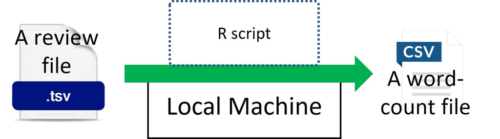

**Figure 1: Single Catrgory Step**

### 2. For all categories

We broadcast our single analysis flow to all categories by CHTC. As the Figure 2 shows, we let each worker in the distributed system perform the computational steps in the Figure 1. So, we will get n’s word count files. Each file is corresponding to a specific category and contains the top 10 terms appearing most frequently in that category.

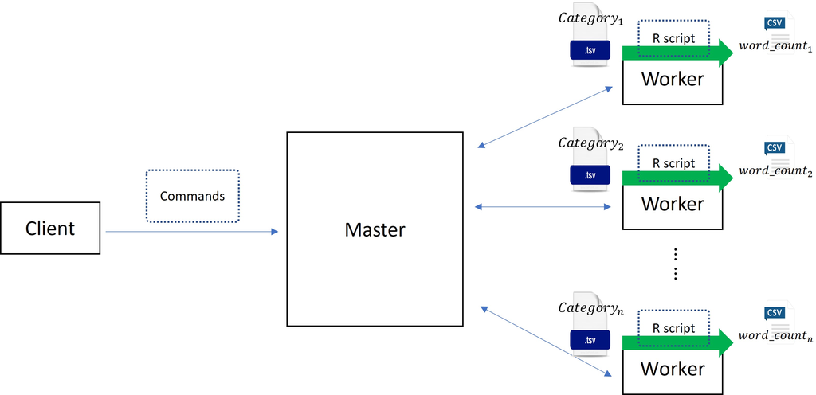

**Figure 2: Distributed Flow Plot**

Also, the number of jobs, runtime for each job, memory and disk space required are listed in the following table.

CHTC Info

| Number.of.Jobs | Runtime | Memeory | Disk.Space |
| --- | --- | --- | --- |
| 24 | 4 hours | 10 GB | 100 GB |